# PART 1 FINAL DM

2025-04-04

Note: Some packages display warnings about being built under R version 4.4.3, while my current environment uses an earlier version. These warnings are non-critical and do not affect the execution or output of the code. All functionality has been tested and works as expected.

#Part I: Unsupervised Learning – Social Media User Segmentation This section explores latent behavioral patterns within a social media user base. Using clustering algorithms, we aim to identify distinct user segments based on interaction and engagement metrics such as posting activity, thread diversity, and like rates. These segments can inform targeted engagement strategies and content personalization.

#EDA & Preprocessing

```r
library(tidyverse)
```

```r
library(cluster)
library(ggplot2)
library(GGally)
library(NbClust)
library(factoextra)
df <- read.csv("dataset_1.csv")

glimpse(df)
```

```
## Rows: 2,307
## Columns: 12
## $ ID                         <int> 0, 1, 2, 3, 4, 5, 6, 7, 8, 9, 10, 11, 12, 1…
## $ TotalReplies               <int> 53, 25, 4, 79, 2, 5, 22, 5, 12, 14, 2, 3, 5…
## $ TotalResponses             <int> 54, 25, 3, 84, 3, 1, 32, 8, 12, 14, 2, 4, 5…
## $ TotalPosts                 <int> 83, 67, 4, 191, 3, 3, 40, 9, 19, 19, 2, 4, …
## $ AverageWordsPerPost        <dbl> 63, 151, 65, 33, 25, 46, 122, 60, 131, 40, …
## $ LikeRate                   <dbl> 0.759036, 0.089552, 0.250000, 0.837696, 0.0…
## $ QuestionsAsked             <dbl> 0.325301, 0.104478, 0.000000, 0.157068, 0.3…
## $ URLSharing                 <dbl> 0.072289, 0.074627, 0.000000, 0.036649, 0.0…
## $ MeanPostsPerThread         <dbl> 1.596154, 2.913043, 2.000000, 1.929293, 1.0…
## $ ConversationInitiationRate <dbl> 0.192308, 0.826087, 0.500000, 0.111111, 0.0…
## $ PostingDiversity           <dbl> 9.222222, 67.000000, 2.000000, 14.692308, 1…
## $ BidirectionalNetwork       <dbl> 0.289157, 0.351351, 0.000000, 0.405172, 0.2…
```

```r
colSums(is.na(df))
```

```
##                         ID               TotalReplies
##                          0                          0
##             TotalResponses                 TotalPosts
##                          0                          0
##        AverageWordsPerPost                   LikeRate
##                          0                          0
##             QuestionsAsked                 URLSharing
##                          0                          0
##         MeanPostsPerThread ConversationInitiationRate
##                          0                          0
##           PostingDiversity       BidirectionalNetwork
##                          0                          0
```

```r
# Summary statistics
summary(df)
```

```
##        ID          TotalReplies    TotalResponses     TotalPosts
##  Min.   :   0.0   Min.   :  0.00   Min.   :  0.00   Min.   :   1.0
##  1st Qu.: 576.5   1st Qu.:  3.00   1st Qu.:  3.00   1st Qu.:   4.0
##  Median :1153.0   Median : 11.00   Median : 10.00   Median :  14.0
##  Mean   :1153.0   Mean   : 36.32   Mean   : 39.36   Mean   :  79.7
##  3rd Qu.:1729.5   3rd Qu.: 42.00   3rd Qu.: 43.00   3rd Qu.:  63.0
##  Max.   :2306.0   Max.   :416.00   Max.   :571.00   Max.   :1835.0
##  AverageWordsPerPost    LikeRate        QuestionsAsked     URLSharing
##  Min.   :   0.00     Min.   : 0.00000   Min.   :0.0000   Min.   :0.00000
##  1st Qu.:  45.12     1st Qu.: 0.08333   1st Qu.:0.1293   1st Qu.:0.00000
##  Median :  75.15     Median : 0.41265   Median :0.2745   Median :0.00000
##  Mean   : 114.69     Mean   : 0.58725   Mean   :0.2959   Mean   :0.06851
##  3rd Qu.: 132.00     3rd Qu.: 0.83333   3rd Qu.:0.4167   3rd Qu.:0.06373
##  Max.   :3118.00     Max.   :16.00000   Max.   :1.0000   Max.   :1.00000
##  MeanPostsPerThread ConversationInitiationRate PostingDiversity
##  Min.   : 1.000     Min.   :0.00000            Min.   :  1.00
##  1st Qu.: 1.190     1st Qu.:0.00000            1st Qu.:  2.00
##  Median : 1.595     Median :0.09302            Median :  4.00
##  Mean   : 2.201     Mean   :0.22969            Mean   :  9.95
##  3rd Qu.: 2.200     3rd Qu.:0.33333            3rd Qu.:  9.50
##  Max.   :87.000     Max.   :2.00000            Max.   :623.00
##  BidirectionalNetwork
##  Min.   :0.00000
##  1st Qu.:0.08333
##  Median :0.23256
##  Mean   :0.23896
##  3rd Qu.:0.35068
##  Max.   :1.00000
```

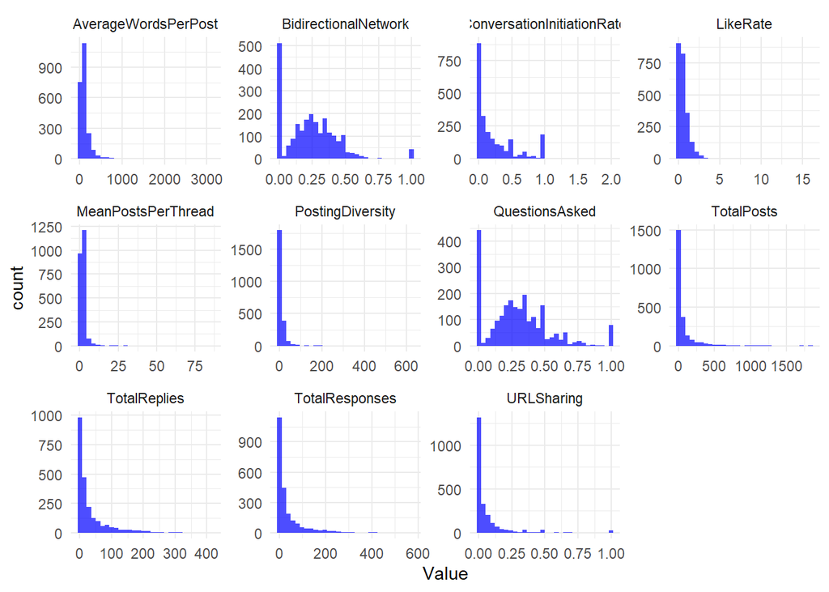

```r
# Check distribution of numeric variables
df %>%
  dplyr::select(-ID) %>%
  gather(key = "Variable", value = "Value") %>%
  ggplot(aes(x = Value)) +
  geom_histogram(bins = 30, fill = "blue", alpha = 0.7) +
  facet_wrap(~ Variable, scales = "free") +
  theme_minimal()
```

#Dataset Overview • A unique ID column was excluded from analysis, since it does not contain information relevant to user behavior.

Most metrics showed right-skewed distributions, indicating that a small percentage of users account for a large portion of activity and engagement.

```r
# Remove ID column (not useful for clustering)
df_clustering <- df %>%
  dplyr::select(-ID)

# Standardize features using z-score
df_scaled <- scale(df_clustering)

summary(df_scaled)
```

```
##   TotalReplies      TotalResponses       TotalPosts       AverageWordsPerPost
##  Min.   :-0.62825   Min.   :-0.58208   Min.   :-0.43012   Min.   :-0.7664
##  1st Qu.:-0.57635   1st Qu.:-0.53772   1st Qu.:-0.41372   1st Qu.:-0.4649
##  Median :-0.43797   Median :-0.43419   Median :-0.35907   Median :-0.2642
##  Mean   : 0.00000   Mean   : 0.00000   Mean   : 0.00000   Mean   : 0.0000
##  3rd Qu.: 0.09827   3rd Qu.: 0.05388   3rd Qu.:-0.09127   3rd Qu.: 0.1157
##  Max.   : 6.56773   Max.   : 7.86289   Max.   : 9.59332   Max.   :20.0692
##     LikeRate       QuestionsAsked       URLSharing       MeanPostsPerThread
##  Min.   :-0.7595   Min.   :-1.25591   Min.   :-0.44355   Min.   :-0.343726
##  1st Qu.:-0.6518   1st Qu.:-0.70704   1st Qu.:-0.44355   1st Qu.:-0.289480
##  Median :-0.2258   Median :-0.09081   Median :-0.44355   Median :-0.173403
##  Mean   : 0.0000   Mean   : 0.00000   Mean   : 0.00000   Mean   : 0.000000
##  3rd Qu.: 0.3183   3rd Qu.: 0.51254   3rd Qu.:-0.03092   3rd Qu.:-0.000355
##  Max.   :19.9343   Max.   : 2.98836   Max.   : 6.03082   Max.   :24.264572
##  ConversationInitiationRate PostingDiversity   BidirectionalNetwork
##  Min.   :-0.7496            Min.   :-0.36867   Min.   :-1.21135
##  1st Qu.:-0.7496            1st Qu.:-0.32748   1st Qu.:-0.78892
##  Median :-0.4460            Median :-0.24509   Median :-0.03245
##  Mean   : 0.0000            Mean   : 0.00000   Mean   : 0.00000
##  3rd Qu.: 0.3382            3rd Qu.:-0.01852   3rd Qu.: 0.56631
##  Max.   : 5.7774            Max.   :25.25414   Max.   : 3.85790
```

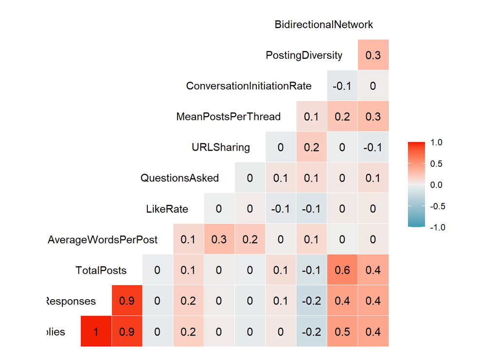

```r
library(GGally)
ggcorr(df_clustering, label = TRUE,hjust=1)
```

• Z-score standardization was applied to all numeric features to normalize scales.

#Clustering Approach

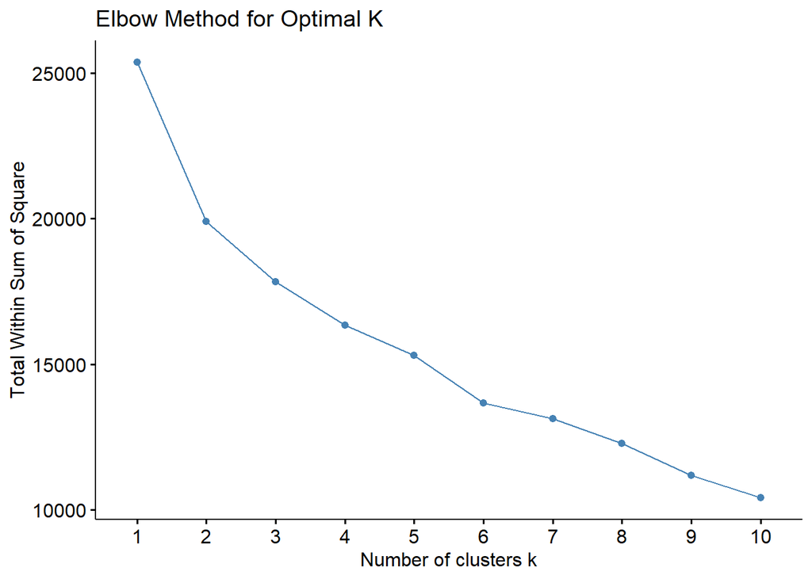

```r
# Elbow Method to find optimal K
fviz_nbclust(df_scaled, kmeans, method = "wss") +
  ggtitle("Elbow Method for Optimal K")
```

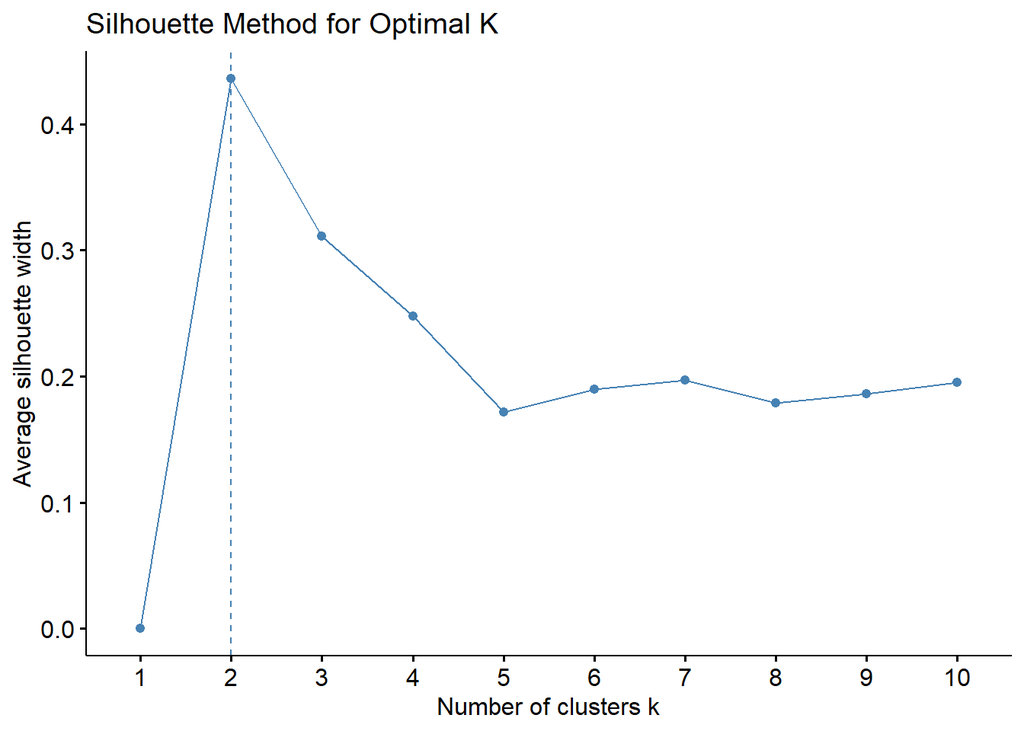

```r
# Silhouette Score to validate clusters
fviz_nbclust(df_scaled, kmeans, method = "silhouette") +
  ggtitle("Silhouette Method for Optimal K")
```

```r
library(caret)
data_scaled <- scale(df_clustering)

data_scaled <- preProcess(df_clustering, method = "range") %>% predict(df_clustering)

# Remove outliers using Z-score
z_scores <- scale(df_clustering)
data_clean <- df_clustering[!rowSums(abs(z_scores) > 3), ]
```

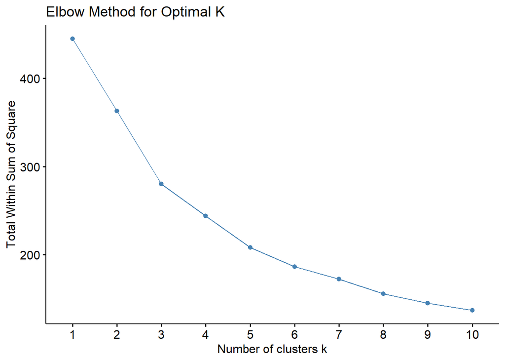

```r
# Elbow Method to find optimal K
fviz_nbclust(data_scaled, kmeans, method = "wss") +
  ggtitle("Elbow Method for Optimal K")
```

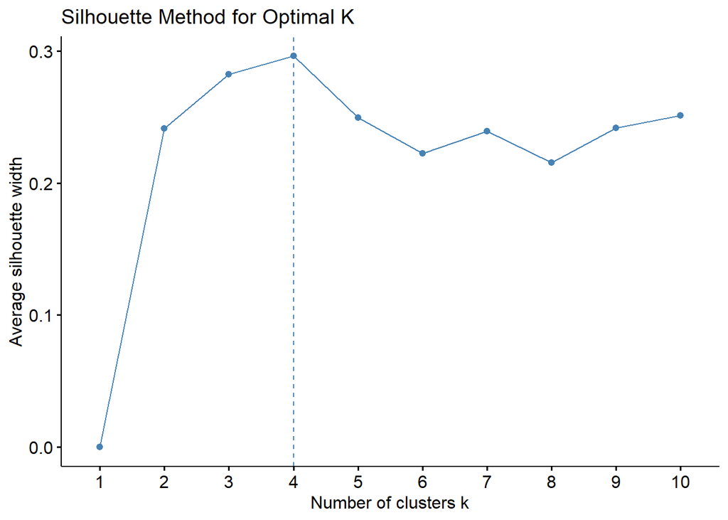

```r
# Silhouette Score to validate clusters
fviz_nbclust(data_scaled, kmeans, method = "silhouette") +
  ggtitle("Silhouette Method for Optimal K")
```

Elbow Method now suggested k = 3 as the point of inflection, supporting a slightly simpler cluster structure.

#Determining the Number of Clusters (k):

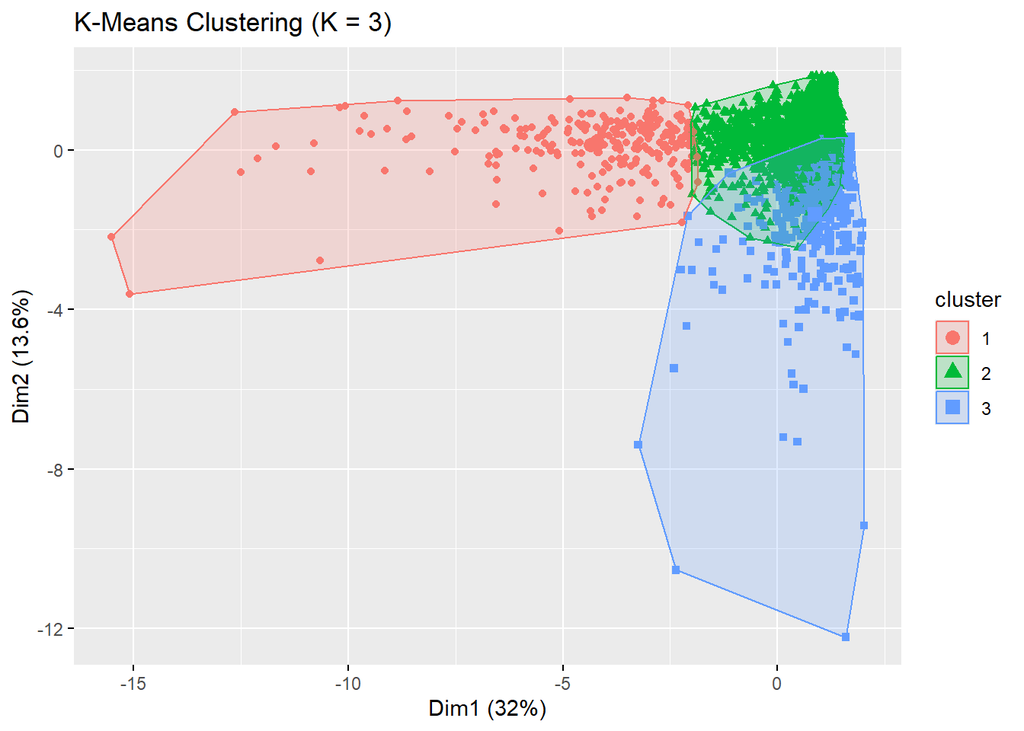

```r
set.seed(123)

# Apply K-Means with K = 3 and K = 4
kmeans_3 <- kmeans(df_scaled, centers = 3, nstart = 25)
kmeans_4 <- kmeans(df_scaled, centers = 4, nstart = 25)

df$Cluster_3 <- as.factor(kmeans_3$cluster)
df$Cluster_4 <- as.factor(kmeans_4$cluster)

# Visualize clusters for K = 3
fviz_cluster(kmeans_3, data = df_scaled, geom = "point") +
  ggtitle("K-Means Clustering (K = 3)")
```

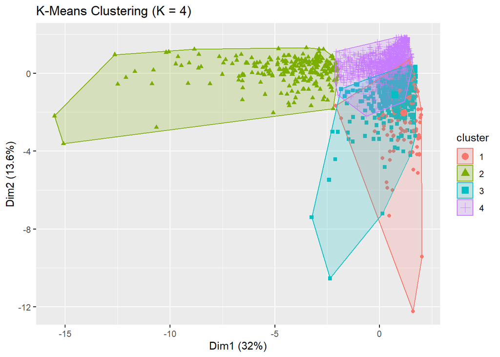

```r
# Visualize clusters for K = 4
fviz_cluster(kmeans_4, data = df_scaled, geom = "point") +
  ggtitle("K-Means Clustering (K = 4)")
```

Clustering Algorithms Applied 1. K-Means Clustering (k = 3): I chose K-means as the primary clustering algorithm because:It handles numerical data well and scales effectively to our dataset size.The feature distributions suggested roughly spherical clusters. It provides interpretable centroids for profiling user segments 2. Hierarchical Clustering (Ward’s Method): Used to cross-validate cluster structure and explore nested relationships.

```r
table(Cluster_3 = df$Cluster_3)
```

```
## Cluster_3
##    1    2    3
##  253 1602  452
```

```r
df$Cluster_3 <- as.factor(kmeans_3$cluster)

# Drop any non-numeric columns like ID or factor variables before summarizing
df_summary <- df %>%
  group_by(Cluster_3) %>%
  summarise(across(where(is.numeric), \(x) mean(x, na.rm = TRUE)))

print(df_summary)
```

```
## # A tibble: 3 × 13
##   Cluster_3    ID TotalReplies TotalResponses TotalPosts AverageWordsPerPost
##   <fct>     <dbl>        <dbl>          <dbl>      <dbl>               <dbl>
## 1 1         1237.       173.           199.        482.                103.
## 2 2         1158.        22.4           23.2        33.6                91.7
## 3 3         1088.         9.23           7.18       17.7               203.
## # ℹ 7 more variables: LikeRate <dbl>, QuestionsAsked <dbl>, URLSharing <dbl>,
## #   MeanPostsPerThread <dbl>, ConversationInitiationRate <dbl>,
## #   PostingDiversity <dbl>, BidirectionalNetwork <dbl>
```

#Results: Cluster Sizes: Cluster 1: 253 users  
Cluster 2: 1602 users  
Cluster 3: 452 users

Cluster 2 dominates in size and shows the highest average silhouette width, suggesting this group is the most well-defined and compact.

Cluster 3 has a negative silhouette width, which indicates overlap or ambiguity with other clusters — these users are poorly assigned and possibly share traits with other groups.

#Silhouette Scores:

```
##   cluster size ave.sil.width
## 1       1  253          0.26
## 2       2 1602          0.44
## 3       3  452         -0.09
```

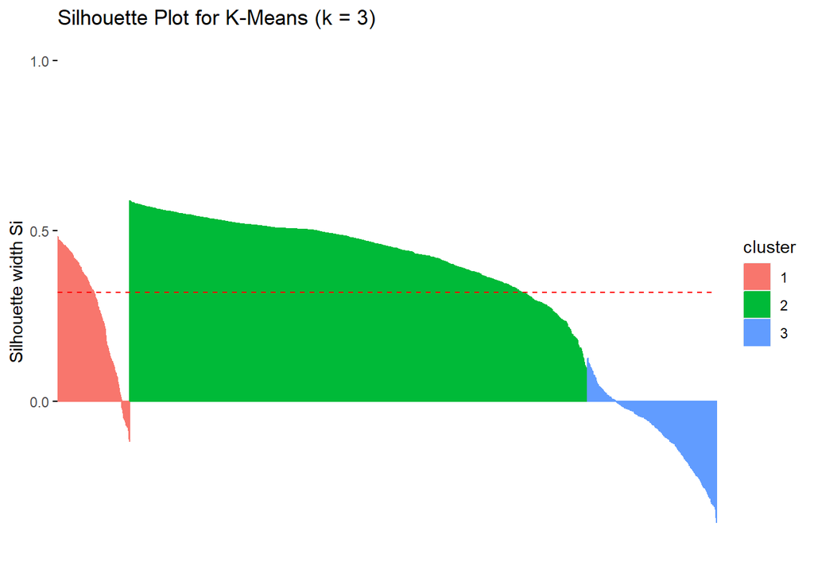

```r
# Silhouette plot for k = 3
library(cluster)
sil <- silhouette(kmeans_3$cluster, dist(df_scaled))
fviz_silhouette(sil) +
  ggtitle("Silhouette Plot for K-Means (k = 3)")
```

Cluster Size Avg. Silhouette Width 1 253 0.26 2 1602 0.44 3 452 -0.09

Cluster 2 dominates in size and shows the highest average silhouette width, suggesting this group is the most well-defined and compact.Cluster 3 has a negative silhouette width, which indicates overlap or ambiguity with other clusters — these users are poorly assigned and possibly share traits with other groups.

#Hierarchical Clustering:

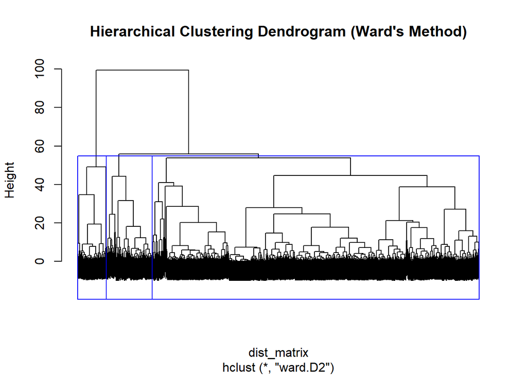

```r
dist_matrix <- dist(df_scaled, method = "euclidean")

hc_model <- hclust(dist_matrix, method = "ward.D2")

plot(hc_model, labels = FALSE, main = "Hierarchical Clustering Dendrogram (Ward's Method)")
rect.hclust(hc_model, k = 3, border = "blue")
```

#K-Means vs. Hierarchical Comparison (Contingency Table)

```r
df$hc_cluster_3 <- cutree(hc_model, k = 3)

# Compare with K-Means clusters
table(KMeans_3 = df$Cluster_3, HC_3 = df$hc_cluster_3)
```

```
##         HC_3
## KMeans_3    1    2    3
##        1   88    1  164
##        2 1504   98    0
##        3  287  163    2
```

Comparing clustering methods revealed that KMeans Cluster 2 and HC Cluster 1 strongly align, suggesting stability, while KMeans Cluster 3 spreads across multiple HC clusters, confirming what the silhouette analysis indicated—Cluster 3 contains borderline or noisy users who don’t fit cleanly into any single behavioral group.

#Interpretation of Low-Silhouette Users in Cluster 3

```r
sil_df <- as.data.frame(sil)
df_inspect <- df %>%
  mutate(cluster = kmeans_3$cluster,
         sil_width = sil_df$sil_width)

# Filter for poorly clustered users (Cluster 3, low silhouette)
cluster3_low <- df_inspect %>%
  filter(cluster == 3, sil_width < 0) %>%
  arrange(sil_width) %>%
  head(10)  # Top 10 worst-fit users

print(cluster3_low)
```

```
##      ID TotalReplies TotalResponses TotalPosts AverageWordsPerPost LikeRate
## 1  1059           19             18         31            110.8387 0.290323
## 2   315           28             32         72            183.0000 0.805556
## 3   233            9             10         12            262.0000 1.000000
## 4  1172           21             13         16             48.3125 0.625000
## 5  2168           19             17         49            224.8980 0.122449
## 6   240           26             25         74             79.0000 0.405405
## 7  1882           17              9         14            117.8571 0.928571
## 8   955           10              8          9            114.7778 1.333333
## 9  2076            1              3          4            178.7500 0.500000
## 10 1603           13              8         12             82.1667 0.250000
##    QuestionsAsked URLSharing MeanPostsPerThread ConversationInitiationRate
## 1        0.322581   0.064516           2.818182                   0.454545
## 2        0.319444   0.263889           2.250000                   0.281250
## 3        0.416667   0.166667           1.200000                   0.300000
```

[output cut: 29 more lines]

Silhouette width values range from -1 to +1. Negative values indicate that: • The user is closer to another cluster’s centroid than to their own • There is overlap or ambiguity in feature space • The user may be misclassified or represents a transitional behavior profile

Analysis of the 10 lowest-scoring users revealed:

Feature Pattern TotalPosts Ranges from low (4) to moderate (74) — no consistency Average Words Per Post Highly variable (48 to 262 words) LikeRate From 0.12 to 1.33 — some are highly liked, some are not ConversationInitiationRate Several above 0.4 — initiators, yet small posting history PostingDiversity Mostly low (< 10), indicating narrow participation BidirectionalNetwork Moderate range (0.17–0.38), no strong cohesion

The 10 lowest silhouette users in Cluster 3 highlight its ambiguity. They show mixed engagement patterns—some post little but get high likes, others start many threads with low network diversity. PostingDiversity is usually low, and BidirectionalNetwork suggests limited two-way interaction. These users blend traits of both passive and selectively engaged types, explaining their poor fit and cluster overlaps. Cluster 3 adds detail but also reveals K-Means’ limits with users showing hybrid behaviors.

#Segment Descriptions: Cluster 1 (Highly Engaged Core): Power users with highest activity levels, diverse contributions, and strong network connections; likely community leaders. Cluster 2 (Moderately Active): Occasional participants with minimal engagement, low post/reply counts, and shorter threads; potentially newer or casual users. Cluster 3 (Selective Contributors): Content specialists who write lengthy posts, initiate discussions, and share resources, but maintain limited ongoing interaction; likely topic experts or knowledge-seekers. Strategic Implications: Nurture Cluster 1 as community pillars, provide engagement incentives for Cluster 2, and develop recognition mechanisms for Cluster 3’s valuable but isolated contributions.

#Conclusion Unsupervised learning revealed three meaningful segments among users, enabling differentiated engagement strategies. While K-means effectively captured core and peripheral behavior patterns, the ambiguity in Cluster 3 highlights limitations with users exhibiting hybrid traits. Still, the clustering provides a practical foundation for community management and content targeting.